# Projeto Ministério da Saúde e Preço-Alimentos

Panosso A.R. & Oliveira J.

19/02/2021

# Entrada de dados

```r
library(tidyverse)
```

```r
library(corrplot)
library(ggpubr)
caminho <- "https://raw.githubusercontent.com/arpanosso/ministerio_saude_alimentos/main/dados/alcatra.txt"
alcatra <- read.table(caminho,h=TRUE,sep="\t")
glimpse(alcatra)
```

```
## Rows: 15
## Columns: 5
## $ Ano     <int> 2005, 2006, 2007, 2008, 2009, 2010, 2011, 2012, 2013, 2014, 20~
## $ IPCA    <dbl> 2.30, 3.75, 25.22, 18.78, -2.35, 33.35, 4.92, -2.41, 3.28, 21.~
## $ ExpBovi <dbl> 1783319747, 2451935575, 2682981110, 3669213800, 2643815489, 33~
## $ pUS     <dbl> 1.97, 2.24, 2.34, 3.82, 3.12, 3.88, 4.82, 4.49, 4.34, 4.55, 4.~
## $ pReais  <dbl> 4.81, 4.88, 4.56, 7.01, 6.23, 6.83, 8.07, 8.78, 9.37, 10.71, 1~
```

# Criando os períodos

```r
alcatra <- alcatra %>%
  mutate(periodo = ifelse(Ano <= 2010,"P1","P2"))
glimpse(alcatra)
```

```
## Rows: 15
## Columns: 6
## $ Ano     <int> 2005, 2006, 2007, 2008, 2009, 2010, 2011, 2012, 2013, 2014, 20~
## $ IPCA    <dbl> 2.30, 3.75, 25.22, 18.78, -2.35, 33.35, 4.92, -2.41, 3.28, 21.~
## $ ExpBovi <dbl> 1783319747, 2451935575, 2682981110, 3669213800, 2643815489, 33~
## $ pUS     <dbl> 1.97, 2.24, 2.34, 3.82, 3.12, 3.88, 4.82, 4.49, 4.34, 4.55, 4.~
## $ pReais  <dbl> 4.81, 4.88, 4.56, 7.01, 6.23, 6.83, 8.07, 8.78, 9.37, 10.71, 1~
## $ periodo <chr> "P1", "P1", "P1", "P1", "P1", "P1", "P2", "P2", "P2", "P2", "P~
```

# Gráfico ao longo do tempo para IPCA e Exportação Bovina

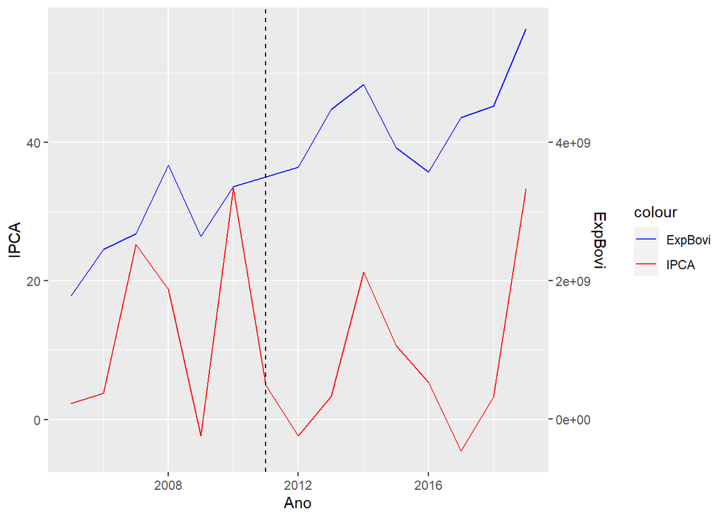

```r
coeff <- 100000000
alcatra %>%
  ggplot(aes(x=Ano)) +
  geom_line( aes(y=IPCA, color = "IPCA")) +
  geom_line( aes(y=ExpBovi  / coeff, color = "ExpBovi")) +
  scale_y_continuous(
    name = "IPCA",
    sec.axis = sec_axis(~.*coeff, name="ExpBovi")
  ) +
  scale_colour_manual(values = c("blue", "red"))+
  geom_vline(xintercept = c(2011),lty=2)
```

# Análise de correlação

## Para o Período 1

```r
alcatra %>%
  filter(Ano < 2011) %>%
  select(-Ano, - periodo) %>%
  cor()
```

```
##              IPCA   ExpBovi       pUS    pReais
## IPCA    1.0000000 0.6552437 0.5202182 0.3238700
## ExpBovi 0.6552437 1.0000000 0.9131342 0.8177104
## pUS     0.5202182 0.9131342 1.0000000 0.9696778
## pReais  0.3238700 0.8177104 0.9696778 1.0000000
```

## Para o Período 2

```r
alcatra %>%
  filter(Ano >= 2011) %>%
  select(-Ano,-periodo) %>%
  cor()
```

```
##               IPCA    ExpBovi         pUS     pReais
## IPCA    1.00000000  0.7263670  0.03341801  0.4669654
## ExpBovi 0.72636698  1.0000000 -0.18315049  0.5547995
## pUS     0.03341801 -0.1831505  1.00000000 -0.8037101
## pReais  0.46696545  0.5547995 -0.80371015  1.0000000
```

# Análise de regressão linear para cada período

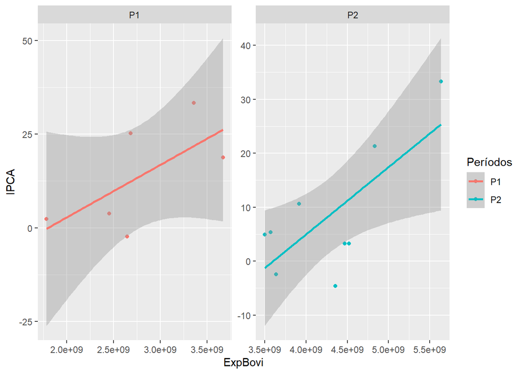

```r
alcatra %>%
  ggplot(aes(x=ExpBovi, y=IPCA, color=as.factor(periodo))) +
  geom_point()+
  geom_smooth(method = "lm")+
  facet_wrap(~periodo,scales = "free")+
  labs(color="Períodos")
```

## Anova para o Periodo 1

A análise de regressão linear foi não significativa pelo teste F ao nível de 5% de probabilidadade (p=0.2751), indicando que não existe uma relação linear entre o IPCA e ExpBovi, denotado pelos baixos valor de R² (0.07704).

```r
da<-alcatra %>%
  filter(Ano <= 2011)
mod <- lm(IPCA~ExpBovi, data=da)
summary.lm(mod)
```

```
##
## Call:
## lm(formula = IPCA ~ ExpBovi, data = da)
##
## Residuals:
##        1        2        3        4        5        6        7
##   0.4989  -4.4995  14.7422  -1.2094 -12.4501  16.3425 -13.4246
##
## Coefficients:
##               Estimate Std. Error t value Pr(>|t|)
## (Intercept) -1.540e+01  2.312e+01  -0.666    0.535
## ExpBovi      9.644e-09  7.872e-09   1.225    0.275
##
## Residual standard error: 12.97 on 5 degrees of freedom
## Multiple R-squared:  0.2309, Adjusted R-squared:  0.07704
## F-statistic: 1.501 on 1 and 5 DF,  p-value: 0.2751
```

## Anova para o Periodo 2

A análise de regressão linear foi significativa pelo teste F ao nível de 5% de probabilidadade (p=0.03073), indicando que existe uma relação linear entre o IPCA e ExpBovi, denotado pelos médios valor de R² (0.4964).

```r
da<-alcatra %>%
  filter(Ano > 2011)
mod <- lm(IPCA~ExpBovi, data=da)
summary.lm(mod)
```

```
##
## Call:
## lm(formula = IPCA ~ ExpBovi, data = da)
##
## Residuals:
##     Min      1Q  Median      3Q     Max
## -13.197  -7.129   2.556   6.912   8.236
##
## Coefficients:
##               Estimate Std. Error t value Pr(>|t|)
## (Intercept) -5.307e+01  2.223e+01  -2.387   0.0542 .
## ExpBovi      1.416e-08  5.037e-09   2.811   0.0307 *
## ---
## Signif. codes:  0 '***' 0.001 '**' 0.01 '*' 0.05 '.' 0.1 ' ' 1
##
## Residual standard error: 9.045 on 6 degrees of freedom
## Multiple R-squared:  0.5684, Adjusted R-squared:  0.4964
## F-statistic:   7.9 on 1 and 6 DF,  p-value: 0.03073
```

# Gráfico ao longo do tempo para IPCA e Preço em Reais

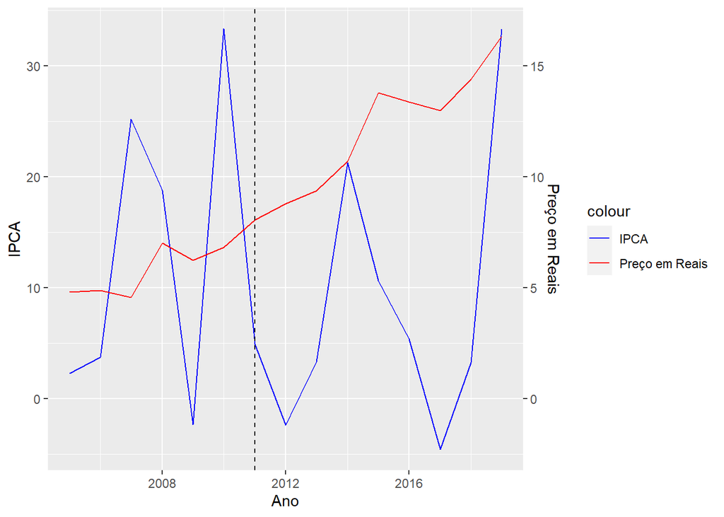

```r
coeff <- .5
alcatra %>%
  ggplot(aes(x=Ano)) +
  geom_line( aes(y=IPCA, color = "IPCA")) +
  geom_line( aes(y=pReais  / coeff, color = "Preço em Reais")) +
  scale_y_continuous(
    name = "IPCA",
    sec.axis = sec_axis(~.*coeff, name="Preço em Reais")
  ) +
  scale_colour_manual(values = c("blue", "red"))+
  geom_vline(xintercept = c(2011),lty=2)
```

# Análise de correlação

## Para o Período 1

```r
alcatra %>%
  filter(Ano < 2011) %>%
  select(-Ano, - periodo) %>%
  cor()
```

```
##              IPCA   ExpBovi       pUS    pReais
## IPCA    1.0000000 0.6552437 0.5202182 0.3238700
## ExpBovi 0.6552437 1.0000000 0.9131342 0.8177104
## pUS     0.5202182 0.9131342 1.0000000 0.9696778
## pReais  0.3238700 0.8177104 0.9696778 1.0000000
```

## Para o Período 2

```r
alcatra %>%
  filter(Ano >= 2011) %>%
  select(-Ano,-periodo) %>%
  cor()
```

```
##               IPCA    ExpBovi         pUS     pReais
## IPCA    1.00000000  0.7263670  0.03341801  0.4669654
## ExpBovi 0.72636698  1.0000000 -0.18315049  0.5547995
## pUS     0.03341801 -0.1831505  1.00000000 -0.8037101
## pReais  0.46696545  0.5547995 -0.80371015  1.0000000
```

# Análise de regressão linear para cada período

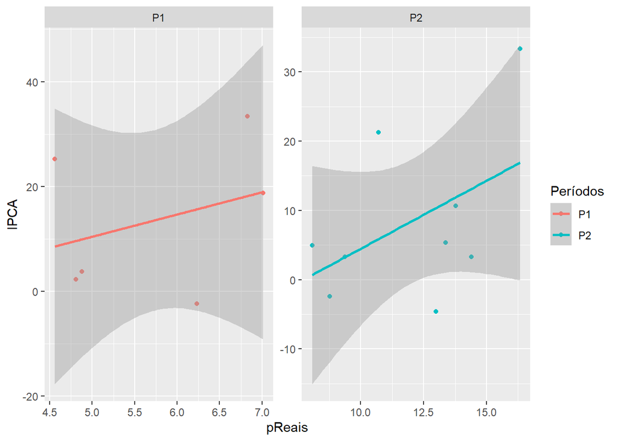

```r
alcatra %>%
  ggplot(aes(x=pReais, y=IPCA, color=as.factor(periodo))) +
  geom_point()+
  geom_smooth(method = "lm")+
  facet_wrap(~periodo,scales = "free")+
  labs(color="Períodos")
```

## Anova para o Periodo 1

A análise de regressão linear foi não significativa pelo teste F ao nível de 5% de probabilidadade (p= 0.8714), indicando que não existe uma relação linear entre o IPCA e pReais, denotado pelos baixos valor de R² (0.005774).

```r
da<-alcatra %>%
  filter(Ano <= 2011)
mod <- lm(IPCA~pReais, data=da)
summary.lm(mod)
```

```
##
## Call:
## lm(formula = IPCA ~ pReais, data = da)
##
## Residuals:
##       1       2       3       4       5       6       7
##  -9.027  -7.631  14.084   5.768 -14.765  20.476  -8.904
##
## Coefficients:
##             Estimate Std. Error t value Pr(>|t|)
## (Intercept)   7.6431    27.7847   0.275    0.794
## pReais        0.7659     4.4949   0.170    0.871
##
## Residual standard error: 14.75 on 5 degrees of freedom
## Multiple R-squared:  0.005774,   Adjusted R-squared:  -0.1931
## F-statistic: 0.02904 on 1 and 5 DF,  p-value: 0.8714
```

## Anova para o Periodo 2

```r
da<-alcatra %>%
  filter(Ano > 2011)
mod <- lm(IPCA~pReais, data=da)
summary.lm(mod)
```

```
##
## Call:
## lm(formula = IPCA ~ pReais, data = da)
##
## Residuals:
##     Min      1Q  Median      3Q     Max
## -14.611  -6.673  -1.847   5.219  16.657
##
## Coefficients:
##             Estimate Std. Error t value Pr(>|t|)
## (Intercept)  -20.623     22.158  -0.931    0.388
## pReais         2.357      1.744   1.352    0.225
##
## Residual standard error: 12.05 on 6 degrees of freedom
## Multiple R-squared:  0.2334, Adjusted R-squared:  0.1057
## F-statistic: 1.827 on 1 and 6 DF,  p-value: 0.2252
```

# Rodada de análise 2

```r
caminho <- "https://raw.githubusercontent.com/arpanosso/ministerio_saude_alimentos/main/dados/rodada2.txt"
ipca <- read.table(caminho,h=TRUE,sep="\t")
glimpse(ipca)
```

```
## Rows: 15
## Columns: 3
## $ Ano  <int> 2005, 2006, 2007, 2008, 2009, 2010, 2011, 2012, 2013, 2014, 2015,~
## $ IPCA <dbl> 100.00, 103.75, 129.92, 154.31, 150.69, 200.94, 210.83, 205.75, 2~
## $ pExp <dbl> 100.00, 101.46, 94.80, 145.74, 129.52, 142.00, 167.78, 182.54, 19~
```

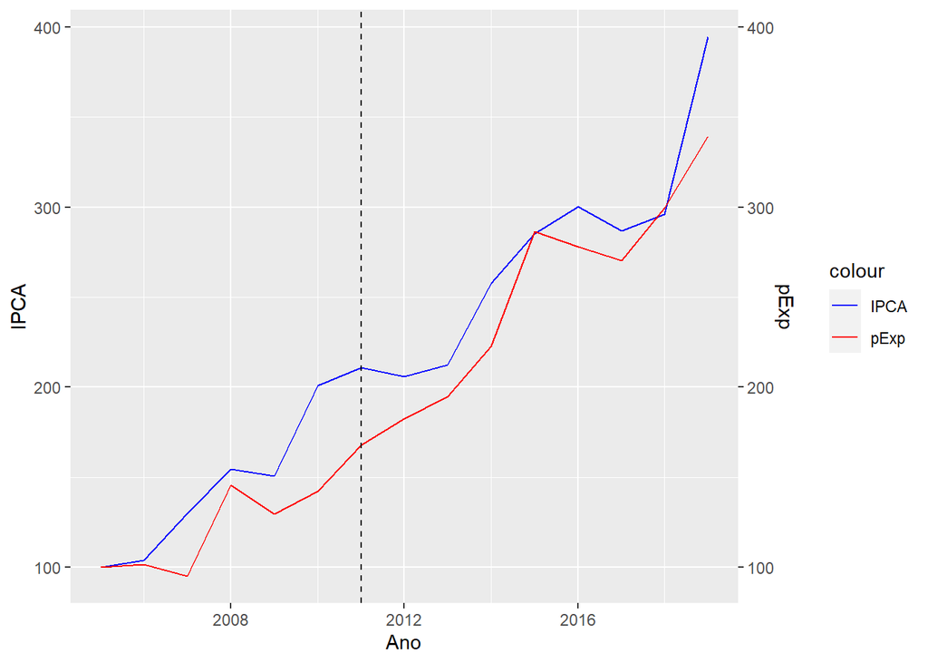

```r
coeff <- 1
ipca %>%
  ggplot(aes(x=Ano)) +
  geom_line( aes(y=IPCA, color = "IPCA")) +
  geom_line( aes(y=pExp   / coeff, color = "pExp")) +
  scale_y_continuous(
    name = "IPCA",
    sec.axis = sec_axis(~.*coeff, name="pExp")
  ) +
  scale_colour_manual(values = c("blue", "red"))+
  geom_vline(xintercept = c(2011),lty=2)
```

# Análise de correlação

## Para o Período TOTAL

```r
ipca %>%
  select(-Ano) %>%
  cor()
```

```
##           IPCA      pExp
## IPCA 1.0000000 0.9715823
## pExp 0.9715823 1.0000000
```

# Análise de regressão linear para cada período

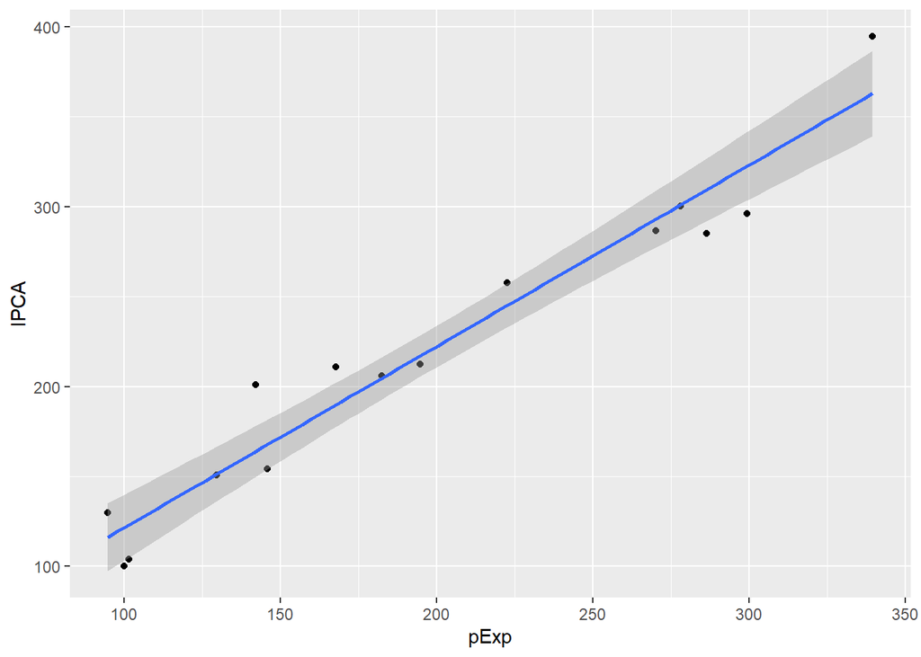

```r
ipca %>%
  ggplot(aes(x=pExp, y=IPCA)) +
  geom_point()+
  geom_smooth(method = "lm")
```

## Anova para o Periodo TOTAL

```r
mod <- lm(IPCA~pExp, data=ipca)
summary.lm(mod)
```

```
##
## Call:
## lm(formula = IPCA ~ pExp, data = ipca)
##
## Residuals:
##     Min      1Q  Median      3Q     Max
## -26.453 -16.250  -0.658  13.115  37.108
##
## Coefficients:
##             Estimate Std. Error t value Pr(>|t|)
## (Intercept) 20.65797   14.43978   1.431    0.176
## pExp         1.00827    0.06813  14.800 1.63e-09 ***
## ---
## Signif. codes:  0 '***' 0.001 '**' 0.01 '*' 0.05 '.' 0.1 ' ' 1
##
## Residual standard error: 20.63 on 13 degrees of freedom
## Multiple R-squared:  0.944,  Adjusted R-squared:  0.9397
## F-statistic:   219 on 1 and 13 DF,  p-value: 1.63e-09
```

# Rodada 3

```r
caminho <- "https://raw.githubusercontent.com/arpanosso/ministerio_saude_alimentos/main/dados/rodada3.txt"
dados <- read.table(caminho,h=TRUE,sep="\t")
glimpse(dados)
```

```
## Rows: 23
## Columns: 4
## $ ano           <int> 1997, 1998, 1999, 2000, 2001, 2002, 2003, 2004, 2005, 20~
## $ IPCA          <dbl> 100.00000, 98.60000, 102.56046, 87.55586, 128.16427, 221~
## $ oleo_soja_exp <dbl> 100.0000, 123.6387, 139.7265, 106.5250, 124.0465, 205.09~
## $ grao_soja_exp <dbl> 100.00000, 85.83221, 102.34711, 109.84601, 129.08528, 17~
```

# Gráfico ao longo do tempo para IPCA e oleo_soja_exp

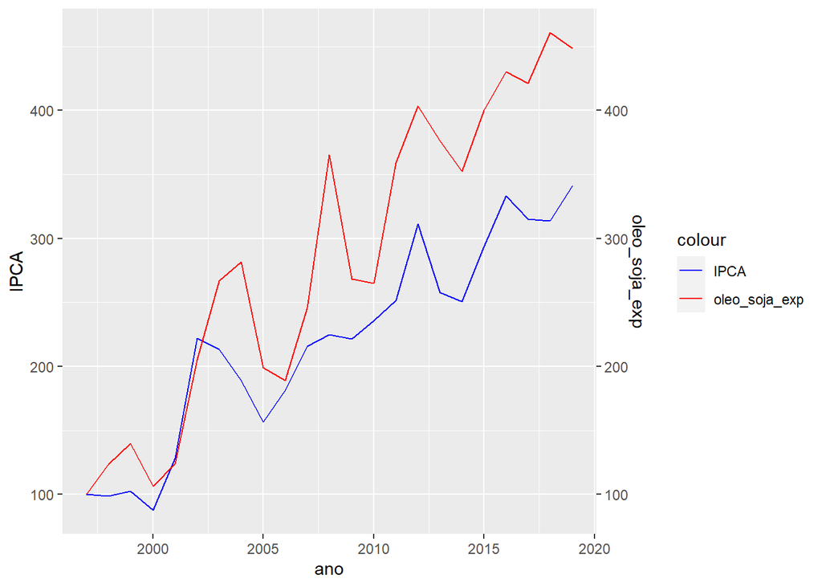

```r
coeff <- 1
dados %>%
  ggplot(aes(x=ano)) +
  geom_line( aes(y=IPCA, color = "IPCA")) +
  geom_line( aes(y=oleo_soja_exp  / coeff, color = "oleo_soja_exp")) +
  scale_y_continuous(
    name = "IPCA",
    sec.axis = sec_axis(~.*coeff, name="oleo_soja_exp")
  ) +
  scale_colour_manual(values = c("blue","red"))
```

# Gráfico ao longo do tempo para IPCA e grao_soja_exp

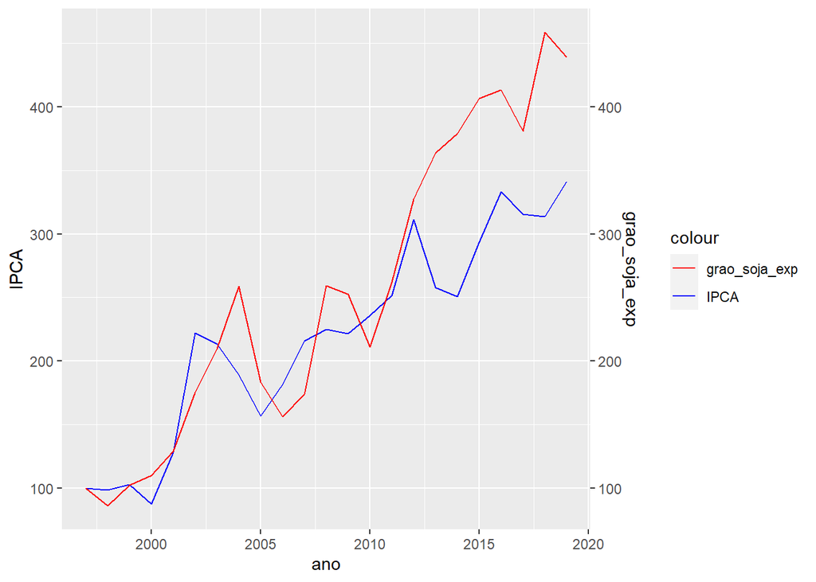

```r
coeff <- 1
dados %>%
  ggplot(aes(x=ano)) +
  geom_line( aes(y=IPCA, color = "IPCA")) +
  geom_line( aes(y=grao_soja_exp  / coeff, color = "grao_soja_exp")) +
  scale_y_continuous(
    name = "IPCA",
    sec.axis = sec_axis(~.*coeff, name="grao_soja_exp")
  ) +
  scale_colour_manual(values = c("red", "blue"))
```

# Análise de correlação

```r
dados %>%
  select(-ano) %>%
  cor()
```

```
##                    IPCA oleo_soja_exp grao_soja_exp
## IPCA          1.0000000     0.9580584     0.9235367
## oleo_soja_exp 0.9580584     1.0000000     0.9593896
## grao_soja_exp 0.9235367     0.9593896     1.0000000
```

# Análise de regressão linear para óleo de soja

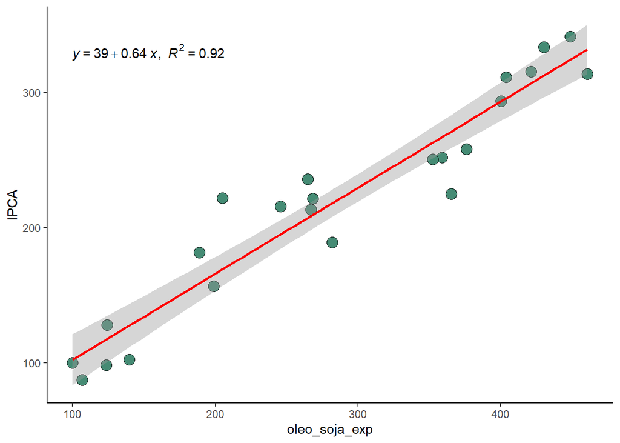

```r
dados %>%
  ggplot(aes(x=oleo_soja_exp, y=IPCA)) +
  geom_point(shape=21, color="black", fill="aquamarine4", size=4)+
  geom_smooth(aes(x=oleo_soja_exp, y=IPCA),method = "lm",color="red") +
  theme_classic()+
  stat_regline_equation(aes(
  label =  paste(..eq.label.., ..rr.label.., sep = "*plain(\",\")~~")))
```

## Anova para óleos de soja

A análise de regressão linear foi significativa pelo teste F ao nível de 1% de probabilidadade (p=<0.001), indicando que existe uma relação linear entre o IPCA e oleo_soja_exp, denotado pelos altos valor de R² (0.92).

```r
da<-dados
mod <- lm(IPCA~oleo_soja_exp, data=da)
summary.lm(mod)
```

```
##
## Call:
## lm(formula = IPCA ~ oleo_soja_exp, data = da)
##
## Residuals:
##     Min      1Q  Median      3Q     Max
## -46.003 -18.463   0.327  16.474  52.550
##
## Coefficients:
##               Estimate Std. Error t value Pr(>|t|)
## (Intercept)   38.91530   12.74058   3.054  0.00602 **
## oleo_soja_exp  0.63557    0.04149  15.320 7.15e-13 ***
## ---
## Signif. codes:  0 '***' 0.001 '**' 0.01 '*' 0.05 '.' 0.1 ' ' 1
##
## Residual standard error: 23.25 on 21 degrees of freedom
## Multiple R-squared:  0.9179, Adjusted R-squared:  0.914
## F-statistic: 234.7 on 1 and 21 DF,  p-value: 7.154e-13
```

# Análise de regressão linear para grao de soja

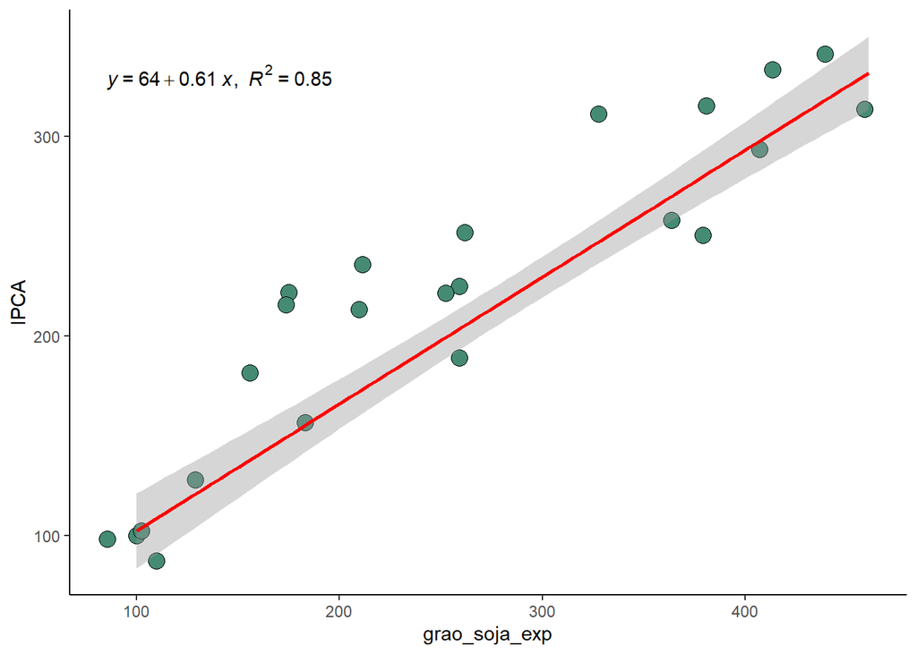

```r
dados %>%
  ggplot(aes(x=grao_soja_exp, y=IPCA)) +
  geom_point(shape=21, color="black", fill="aquamarine4", size=4)+
  geom_smooth(aes(x=oleo_soja_exp, y=IPCA),method = "lm",color="red") +
  theme_classic()+
  stat_regline_equation(aes(
  label =  paste(..eq.label.., ..rr.label.., sep = "*plain(\",\")~~")))
```

## Anova para grãos de soja

A análise de regressão linear foi significativa pelo teste F ao nível de 1% de probabilidadade (p<0.001), indicando que existe uma relação linear entre o IPCA e grao_soja_exp, denotado pelos altos valor de R² (0.85).

```r
da<-dados
mod <- lm(IPCA~grao_soja_exp, data=da)
summary.lm(mod)
```

```
##
## Call:
## lm(formula = IPCA ~ grao_soja_exp, data = da)
##
## Residuals:
##     Min      1Q  Median      3Q     Max
## -45.189 -24.964   2.434  21.203  50.352
##
## Coefficients:
##               Estimate Std. Error t value Pr(>|t|)
## (Intercept)   64.49419   15.46578    4.17 0.000433 ***
## grao_soja_exp  0.61034    0.05531   11.04 3.36e-10 ***
## ---
## Signif. codes:  0 '***' 0.001 '**' 0.01 '*' 0.05 '.' 0.1 ' ' 1
##
## Residual standard error: 31.12 on 21 degrees of freedom
## Multiple R-squared:  0.8529, Adjusted R-squared:  0.8459
## F-statistic: 121.8 on 1 and 21 DF,  p-value: 3.36e-10
```

# Bovinocultura

```r
caminho <- "https://raw.githubusercontent.com/arpanosso/ministerio_saude_alimentos/main/bovinocultura.txt"
dados <- read.table(caminho,h=TRUE,sep="\t")
glimpse(dados)
```

```
## Rows: 23
## Columns: 3
## $ ano        <int> 1997, 1998, 1999, 2000, 2001, 2002, 2003, 2004, 2005, 2006,~
## $ IPCA       <dbl> 100.0, 105.1, 129.4, 131.4, 149.8, 168.8, 181.4, 192.4, 198~
## $ precoExpor <dbl> 100.0, 101.9, 138.5, 121.7, 116.3, 129.0, 134.2, 151.3, 134~
```

# Gráfico ao longo do tempo para IPCA e Bovinocultura de Exportação

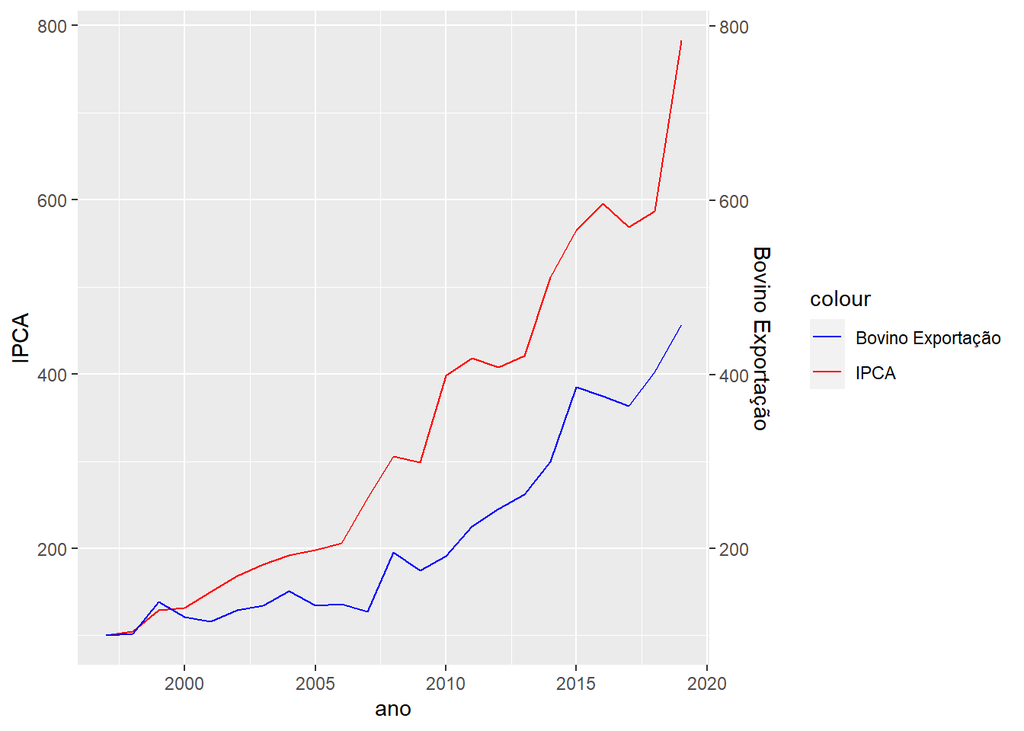

```r
coeff <- 1
dados %>%
  ggplot(aes(x=ano)) +
  geom_line( aes(y=IPCA, color = "IPCA")) +
  geom_line( aes(y=precoExpor  / coeff, color = "Bovino Exportação")) +
  scale_y_continuous(
    name = "IPCA",
    sec.axis = sec_axis(~.*coeff, name="Bovino Exportação")
  ) +
  scale_colour_manual(values = c("blue","red"))
```

# Análise de correlação

```r
dados %>%
  select(-ano) %>%
  cor()
```

```
##                 IPCA precoExpor
## IPCA       1.0000000  0.9723961
## precoExpor 0.9723961  1.0000000
```

# Análise de regressão linear para Bovinocultura Exportação e IPCA

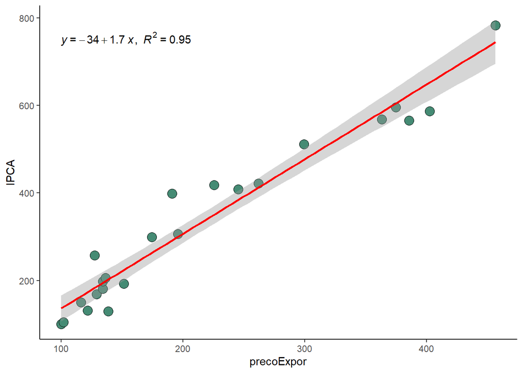

```r
dados %>%
  ggplot(aes(x=precoExpor, y=IPCA)) +
  geom_point(shape=21, color="black", fill="aquamarine4", size=4)+
  geom_smooth(aes(x=precoExpor, y=IPCA),method = "lm",color="red") +
  theme_classic()+
  stat_regline_equation(aes(
  label =  paste(..eq.label.., ..rr.label.., sep = "*plain(\",\")~~")))
```

## Anova para Bovinocultura Exportação e IPCA

A análise de regressão linear foi significativa pelo teste F ao nível de 1% de probabilidadade (p=<0.001), indicando que existe uma relação linear entre o IPCA e Bovinocultura Exportação, denotado pelos altos valor de R² (0.9456).

```r
da<-dados
mod <- lm(IPCA~precoExpor, data=da)
summary.lm(mod)
```

```
##
## Call:
## lm(formula = IPCA ~ precoExpor, data = da)
##
## Residuals:
##     Min      1Q  Median      3Q     Max
## -72.580 -32.934  -8.824  29.386 107.251
##
## Coefficients:
##              Estimate Std. Error t value Pr(>|t|)
## (Intercept) -34.23456   21.58960  -1.586    0.128
## precoExpor    1.70552    0.08931  19.097 9.43e-15 ***
## ---
## Signif. codes:  0 '***' 0.001 '**' 0.01 '*' 0.05 '.' 0.1 ' ' 1
##
## Residual standard error: 46.55 on 21 degrees of freedom
## Multiple R-squared:  0.9456, Adjusted R-squared:  0.943
## F-statistic: 364.7 on 1 and 21 DF,  p-value: 9.427e-15
```

#Avicultura

```r
caminho <- "https://raw.githubusercontent.com/arpanosso/ministerio_saude_alimentos/main/avicultura.txt"
dados <- read.table(caminho,h=TRUE,sep="\t")
glimpse(dados)
```

```
## Rows: 23
## Columns: 3
## $ ano      <int> 1997, 1998, 1999, 2000, 2001, 2002, 2003, 2004, 2005, 2006, 2~
## $ IPCA     <dbl> 100.00, 100.26, 126.23, 135.05, 139.95, 173.54, 196.17, 201.6~
## $ precoExp <dbl> 100.00, 100.72, 142.15, 112.48, 167.13, 167.24, 179.95, 206.3~
```

# Gráfico ao longo do tempo para IPCA e Avicultura de Exportação

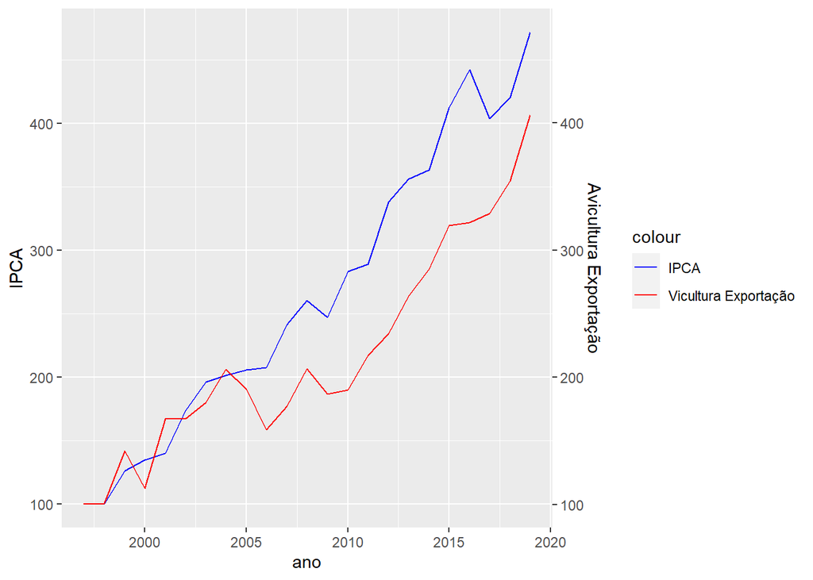

```r
coeff <- 1
dados %>%
  ggplot(aes(x=ano)) +
  geom_line( aes(y=IPCA, color = "IPCA")) +
  geom_line( aes(y=precoExp  / coeff, color = "Vicultura Exportação")) +
  scale_y_continuous(
    name = "IPCA",
    sec.axis = sec_axis(~.*coeff, name="Avicultura Exportação")
  ) +
  scale_colour_manual(values = c("blue","red"))
```

# Análise de correlação

```r
dados %>%
  select(-ano) %>%
  cor()
```

```
##              IPCA precoExp
## IPCA     1.000000 0.960948
## precoExp 0.960948 1.000000
```

# Análise de regressão linear para Avicultura Exportação e IPCA

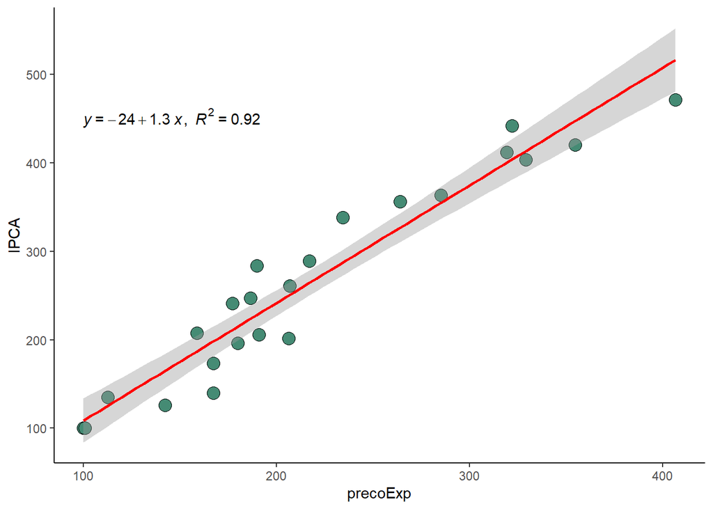

```r
dados %>%
  ggplot(aes(x=precoExp, y=IPCA)) +
  geom_point(shape=21, color="black", fill="aquamarine4", size=4)+
  geom_smooth(aes(x=precoExp, y=IPCA),method = "lm",color="red") +
  theme_classic()+
  stat_regline_equation(aes(
  label =  paste(..eq.label.., ..rr.label.., sep = "*plain(\",\")~~")))
```

## Anova para Avicultura Exportação e IPCA

A análise de regressão linear foi significativa pelo teste F ao nível de 1% de probabilidadade (p=<0.001), indicando que existe uma relação linear entre o IPCA e Avicultura Exportação, denotado pelos altos valor de R² (0.9234).

```r
da<-dados
mod <- lm(IPCA~precoExp, data=da)
summary.lm(mod)
```

```
##
## Call:
## lm(formula = IPCA ~ precoExp, data = da)
##
## Residuals:
##     Min      1Q  Median      3Q     Max
## -58.080 -24.072   8.366  23.997  55.176
##
## Coefficients:
##              Estimate Std. Error t value Pr(>|t|)
## (Intercept) -24.23077   19.46830  -1.245    0.227
## precoExp      1.32987    0.08357  15.913 3.42e-13 ***
## ---
## Signif. codes:  0 '***' 0.001 '**' 0.01 '*' 0.05 '.' 0.1 ' ' 1
##
## Residual standard error: 32.75 on 21 degrees of freedom
## Multiple R-squared:  0.9234, Adjusted R-squared:  0.9198
## F-statistic: 253.2 on 1 and 21 DF,  p-value: 3.424e-13
```

# Análise Café

```r
caminho <- "https://raw.githubusercontent.com/arpanosso/ministerio_saude_alimentos/main/dados/cafe_porco.txt"
dados <- read.table(caminho,h=TRUE,sep="\t")
glimpse(dados)
```

```
## Rows: 23
## Columns: 7
## $ Ano              <int> 1997, 1998, 1999, 2000, 2001, 2002, 2003, 2004, 2005,~
## $ cafe_IPCA        <dbl> 100.00, 86.88, 88.12, 85.73, 97.09, 108.37, 117.87, 1~
## $ cafe_soluvel     <dbl> 100.00, 104.99, 120.71, 112.12, 108.57, 119.60, 143.9~
## $ cafe_torrado     <dbl> 100.00, 120.88, 124.27, 100.12, 62.86, 64.52, 143.47,~
## $ carne_porco_IPCA <dbl> 100.00, 115.40, 142.30, 142.19, 163.60, 170.91, 206.1~
## $ carne_suina      <dbl> 100.00, 86.68, 101.96, 97.52, 132.92, 133.44, 143.96,~
## $ miudos           <dbl> 100.00, 87.98, 100.26, 103.71, 129.87, 122.10, 150.48~
```

# Gráfico ao longo do tempo para IPCA e Café Soluvel

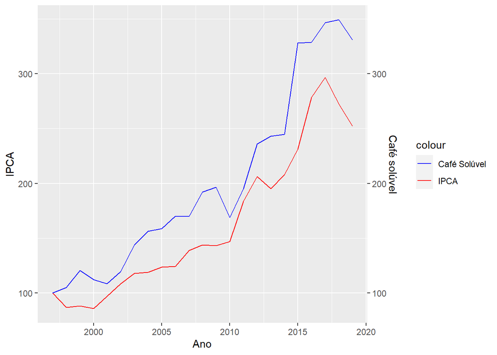

```r
coeff <- 1
dados %>%
  ggplot(aes(x=Ano)) +
  geom_line( aes(y=cafe_IPCA, color = "IPCA")) +
  geom_line( aes(y=cafe_soluvel  / coeff, color = "Café Solúvel")) +
  scale_y_continuous(
    name = "IPCA",
    sec.axis = sec_axis(~.*coeff, name="Café solúvel")
  ) +
  scale_colour_manual(values = c("blue","red"))
```

# Análise de correlação

```r
dados %>%
  select(-Ano) %>%
  cor()
```

```
##                  cafe_IPCA cafe_soluvel cafe_torrado carne_porco_IPCA
## cafe_IPCA        1.0000000    0.9783425    0.9723043        0.9311386
## cafe_soluvel     0.9783425    1.0000000    0.9813015        0.9455735
## cafe_torrado     0.9723043    0.9813015    1.0000000        0.9266041
## carne_porco_IPCA 0.9311386    0.9455735    0.9266041        1.0000000
## carne_suina      0.9057075    0.9296316    0.9108481        0.9704174
## miudos           0.9701877    0.9731855    0.9673630        0.9476139
##                  carne_suina    miudos
## cafe_IPCA          0.9057075 0.9701877
## cafe_soluvel       0.9296316 0.9731855
## cafe_torrado       0.9108481 0.9673630
## carne_porco_IPCA   0.9704174 0.9476139
## carne_suina        1.0000000 0.9511940
## miudos             0.9511940 1.0000000
```